# Analyze results of log2 transformation experiment

Jaclyn Taroni

2025

This notebook is to examine if methods are invariant to the input data being log2 transformed. The prediction on transformed data is performed in `predict/predict_log2_transformation.R`.

Our hypothesis is that the pair-based models (i.e., kTSP and RF) will be uniquely high performing across conditions (i.e., be unaffected by transformation).

## Set up

### Libraries

```r
library(ggplot2)
```

### Functions

```r
wrangle_kappa <- function(dataset) {
  # For a dataset-transformation pair with 1 or more models associated with it,
  # return a data frame that reports the Kappa values

  # Only retain the parts of the list that have metrics in them
  dataset_metrics <- dataset[-which(names(dataset)
                                    %in% c("dataset", "transformation"))]

  # Extract the Kappa values
  kappa_values <- dataset_metrics |>
    purrr::map(\(x) x$cm$overall[["Kappa"]])

  # Return data frame of Kappa values for the relevant dataset-transformation
  # combination
  df <- data.frame(
    study = dataset$dataset,
    transformation = dataset$transformation,
    model_type = names(kappa_values),
    metric = "Kappa",
    value = unlist(kappa_values)
  )
  # Otherwise rownames will be names(kappa_values)
  rownames(df) <- NULL
  return(df)

}
```

### Directories and files

```r
results_dir <- here::here("results")
plots_dir <- here::here("plots")
plots_data_dir <- here::here("plots/data")

# To get Kappa values from baseline bulk experiments
baseline_predictions_filepath <- file.path(
  plots_data_dir,
  "baseline_plots_df.tsv"
)

# Used to extract Kappa values from the log2 transformation experiments
transformation_results_filepath <- file.path(
  results_dir,
  "log2_transformation_prediction_results.rds"
)

# Output files
kappa_df_filepath <- file.path(plots_data_dir,
                               "transformation_experiment_kappa_df.tsv")
kappa_plot_filepath <- file.path(plots_dir,
                                 "transformation_experiment_kappa_barplot.pdf")
```

## Read in data

### Baseline results

For most models, we’ve already tested predicting on bulk TPM data during baseline model training/testing. For medulloPackage, we’ve already tested predicting on log2(TPM + 1) in baseline model training/testing. We will read those results in here and plot them alongside results generated in `predict/predict_log2_transformation.R`.

```r
baseline_results_df <- readr::read_tsv(baseline_predictions_filepath,
                                       progress = FALSE,
                                       show_col_types = FALSE)

# Grab just the values we need from the baseline results
baseline_results_df <- baseline_results_df |>
  # Same indices as in predict/predict_log2_transformation.R
  dplyr::filter(repeat_index %in% c(6, 8, 10),
                platform == "RNA-seq",
                metric == "Kappa",
                # These models were not considered in the transformation
                # experiment
                !(model_type %in% c("RF (unw)", "kTSP (w)"))) |>
  # In the baseline results, only medulloPackage uses log2 transformed data
  dplyr::mutate(transformation = dplyr::case_when(
    model_type == "medulloPackage" ~ "log2",
    TRUE ~ "untransformed"
  )) |>
  # Only select the columns we'll have in the transformation metrics data frame
  dplyr::select(
    study,
    transformation,
    model_type,
    metric,
    value
  )
```

### Transformation experiment

In `predict/predict_log2_transformation.R`, we generated an RDS file that contains the test results and confusion matrices for various dataset-transformation pairs. We need to read that in and extract the Kappa values for plotting.

```r
transformation_results_list <- readr::read_rds(transformation_results_filepath)

# Create a data frame of Kappa values
transform_kappa_df <- transformation_results_list |>
  purrr::map(\(x) wrangle_kappa(x)) |>
  dplyr::bind_rows() |>
  dplyr::mutate(model_type = dplyr::case_match(
    model_type,
    "ktsp_unweighted" ~ "kTSP (unw)",
    "rf_weighted" ~ "RF (w)",
    "medullopackage" ~ "medulloPackage",
    "mm2s" ~ "MM2S",
    "lasso" ~ "LASSO"
  )
)
```

### Combine results

Combine the results from the baseline models and the transformation experiment and save to file.

```r
all_results_df <- baseline_results_df |>
  dplyr::bind_rows(transform_kappa_df) |>
  # Keep track of bulk vs. pseudobulk
  dplyr::mutate(platform = dplyr::case_when(
    study %in% c("GSE119926", "GSE155446") ~ "pseudobulk",
    TRUE ~ "bulk"
  )) |>
  # Order variables for plotting
  dplyr::mutate(
    # Put pseudobulk last
    study = factor(study,
                   levels = c("GSE164677", "OpenPBTA", "St. Jude",
                              "GSE119926", "GSE155446")),
    # Put untransformed first, as that is what the bulk of the methods expect
    transformation = factor(transformation,
                            levels = c("untransformed", "log2"))
  )

readr::write_tsv(all_results_df, file = kappa_df_filepath)
```

## Plotting

Create a bar plot with labels above the bar.

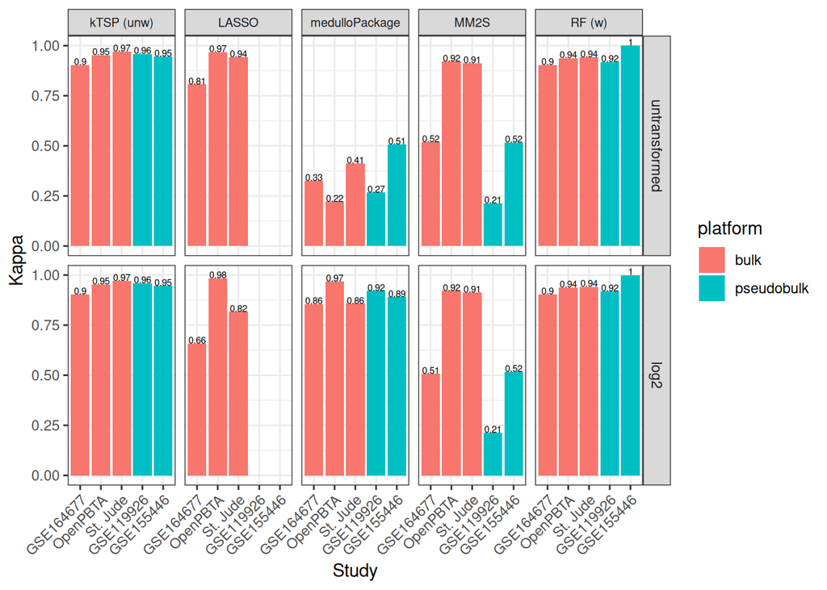

```r
bar_plot <- all_results_df |>
  ggplot(aes(
    x = study,
    y = value,
    fill = platform
  )) +
  geom_bar(stat = "identity") +
  geom_text(
    aes(label = round(value, 2)),
    vjust = 0,
    size = 2
  ) +
  facet_grid(rows = vars(transformation),
             cols = vars(model_type)) +
  theme_bw() +
  theme(axis.text.x = element_text(angle = 45, hjust = 1),
        strip.text.x = element_text(size = 7.5)) +
  labs(x = "Study",
       y = "Kappa")

bar_plot
```

```r
ggsave(bar_plot,
       filename = kappa_plot_filepath,
       width = 7,
       height = 5)
```